# Module 5: Peer Reviewed Assignment

### Outline:

The objectives for this assignment:

1. Understand what can cause violations in the linear regression assumptions.
2. Enhance your skills in identifying and diagnosing violated assumptions.
3. Learn some basic methods of addressing violated assumptions.

General tips:

1. Read the questions carefully to understand what is being asked.
2. This work will be reviewed by another human, so make sure that you are clear and concise in what your explanations and answers.

```r
# Load Required Packages
library(ggplot2)
```

## Problem 1: Let's Violate Some Assumptions!

When looking at a single plot, it can be difficult to discern the different assumptions being violated. In the following problem, you will simulate data that purposefully violates each of the four linear regression assumptions. Then we can observe the different diagnostic plots for each of those assumptions.

#### 1. (a) Linearity

Generate SLR data that violates the linearity assumption, but maintains the other assumptions. Create a scatterplot for these data using ggplot.

Then fit a linear model to these data and comment on where you can diagnose nonlinearity in the diagnostic plots.

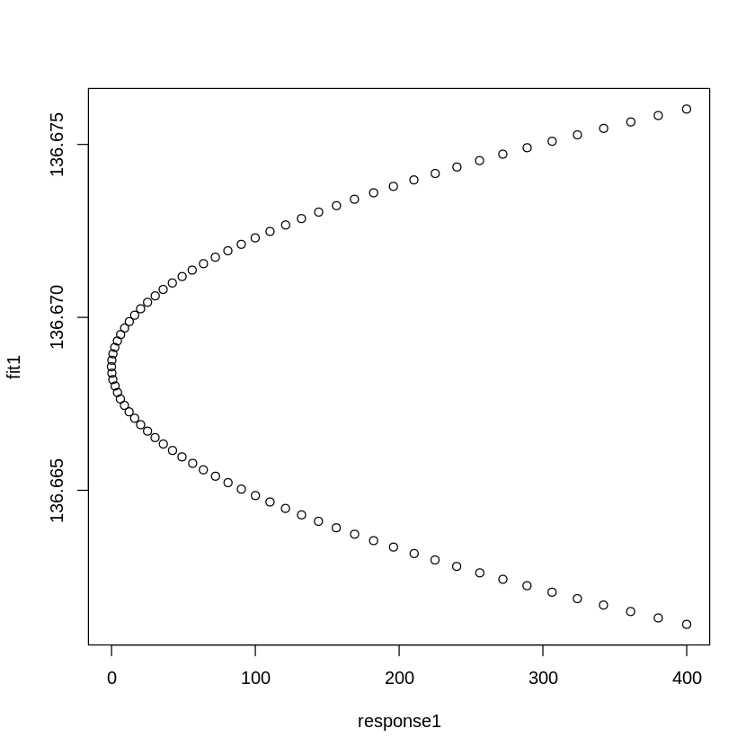

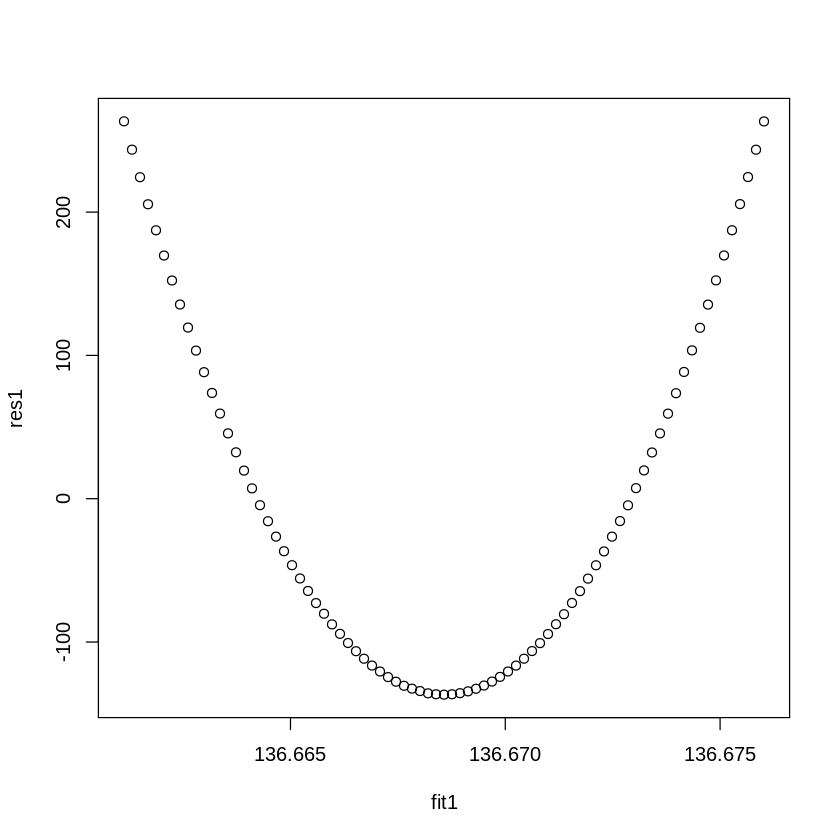

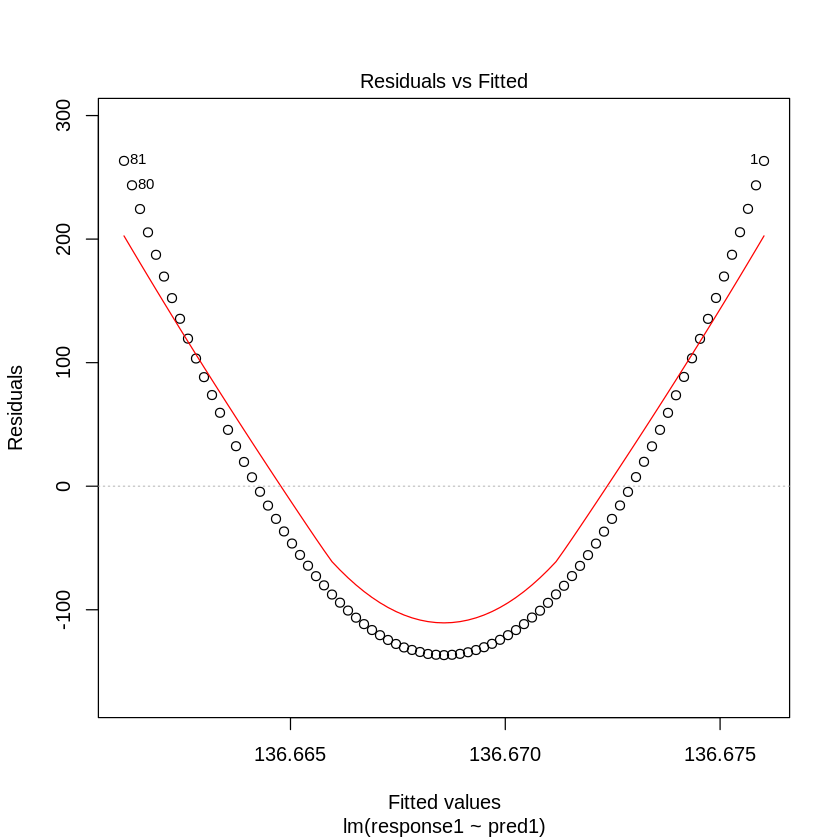

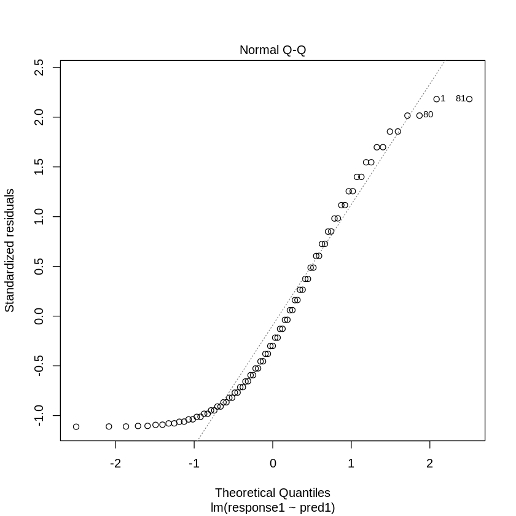

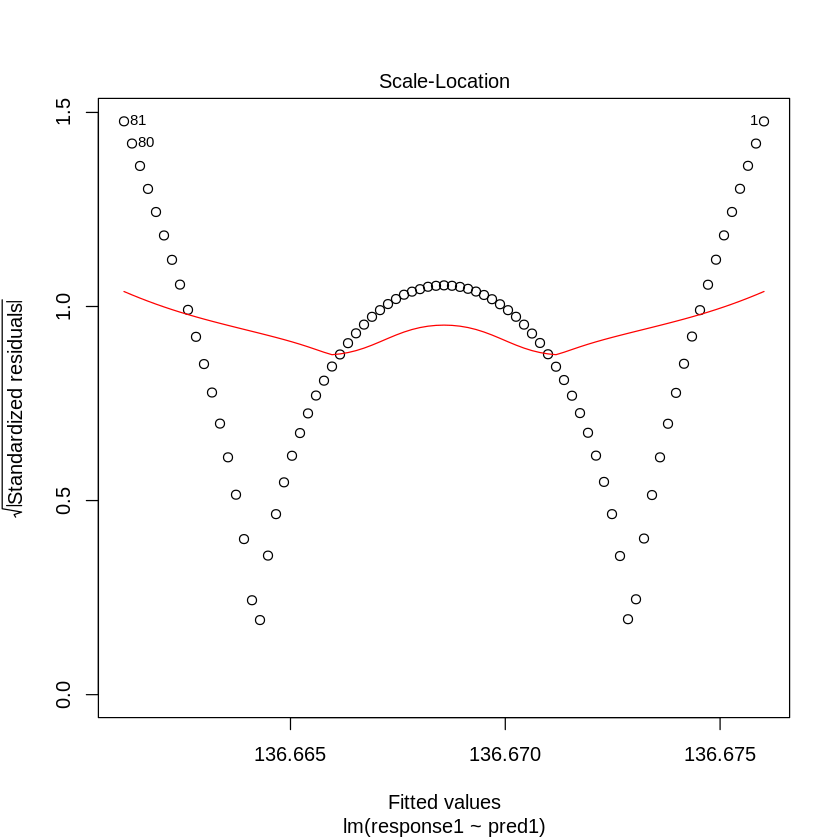

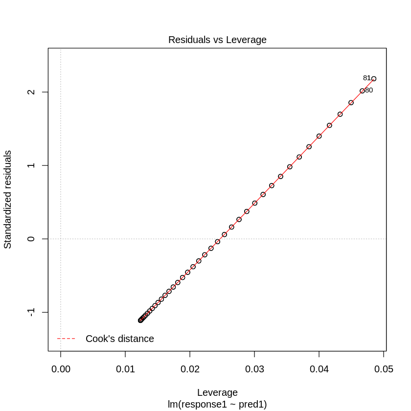

```r
# Your Code Here
set.seed(123)
pred1 <- seq(-20, 20, 0.5)
response1 <- pred1 ^ 2 + rnorm(n = length(pred1), mean = 0, sd = 0.1)

new_df1 <- data.frame(cbind(pred1, response1))
non_lin_mod <- lm(response1 ~ pred1, data = new_df1)
fit1 <- fitted(non_lin_mod)
res1 <- resid(non_lin_mod)

plot(response1, fit1)
plot(fit1, res1)
plot(non_lin_mod)
```

Examining the plot of the fitted values vs the residual values shows that the data is exhibiting quadratic polynomial behavior, instead of a positive linear trend that we would expect for SLR.

#### 1. (b) Homoskedasticity

Simulate another SLR dataset that violates the constant variance assumption, but maintains the other assumptions. Then fit a linear model to these data and comment on where you can diagnose non-constant variance in the diagnostic plots.

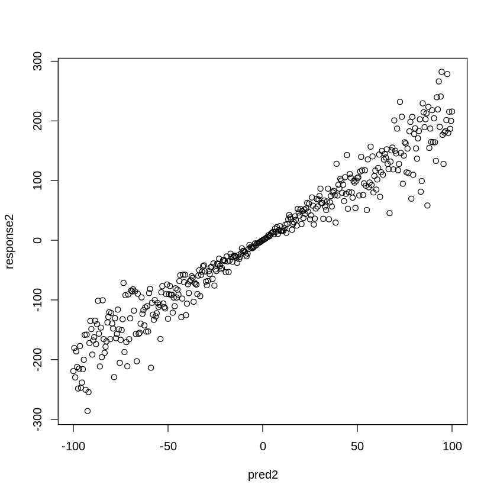

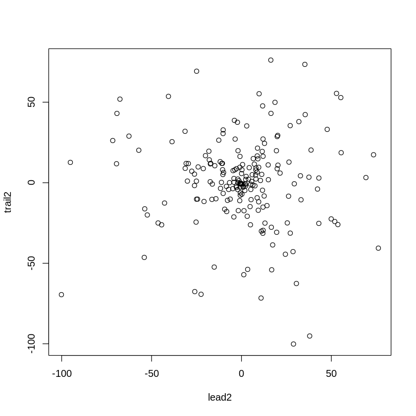

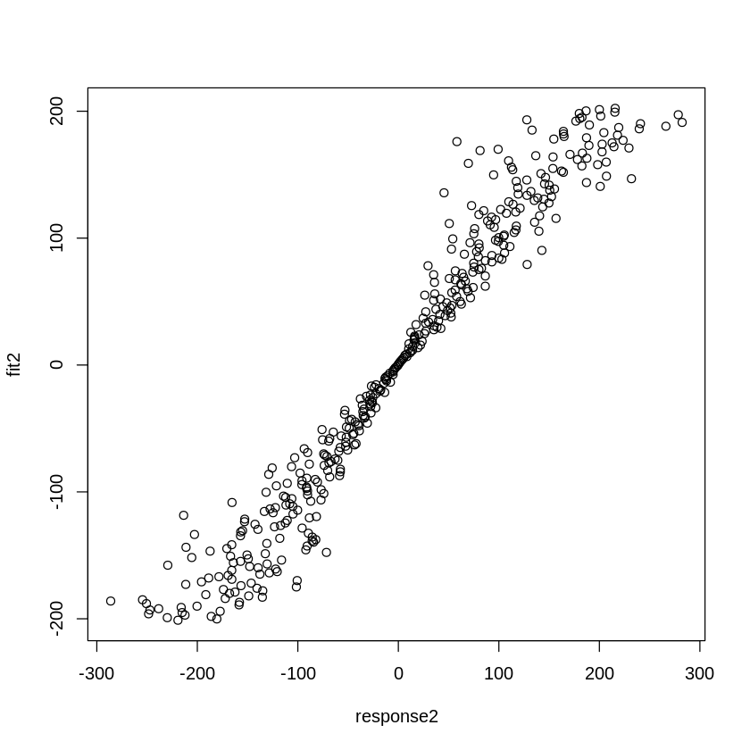

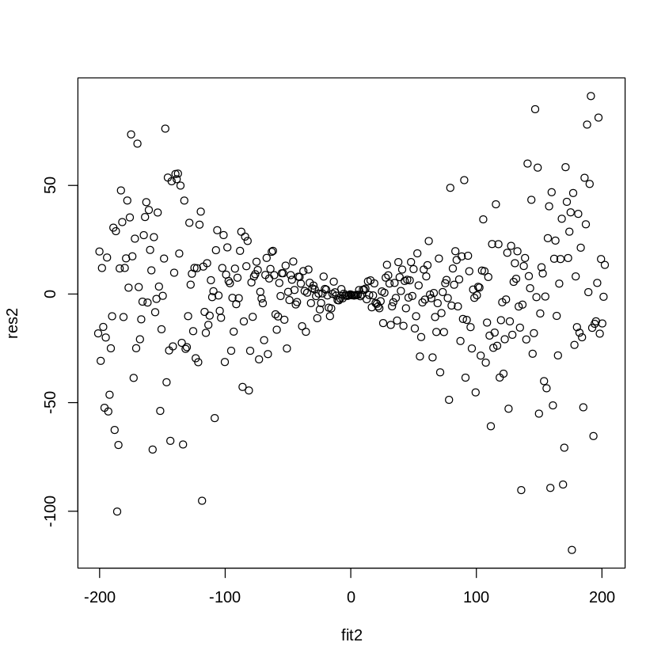

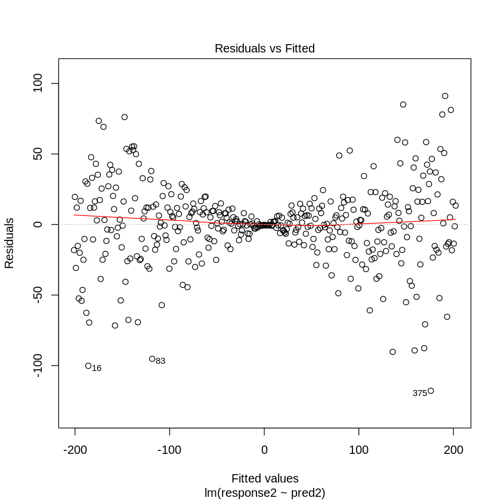

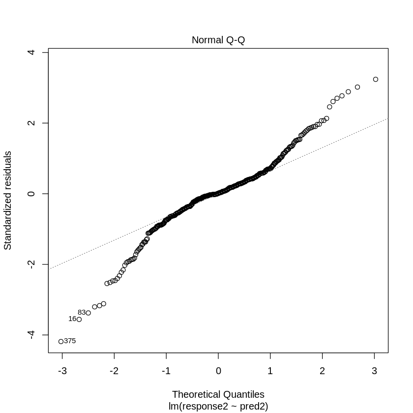

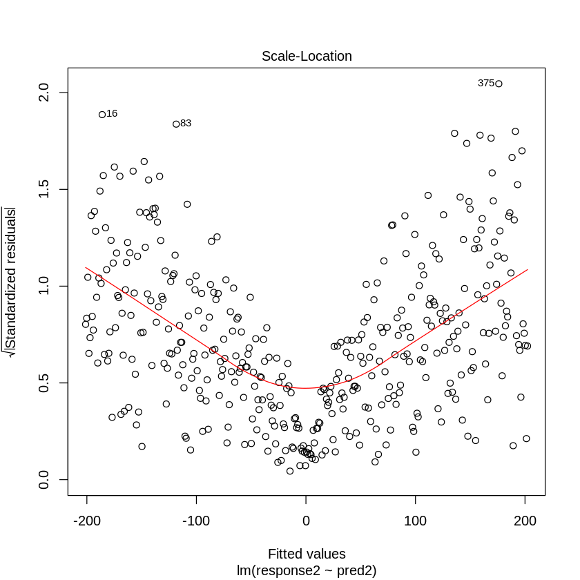

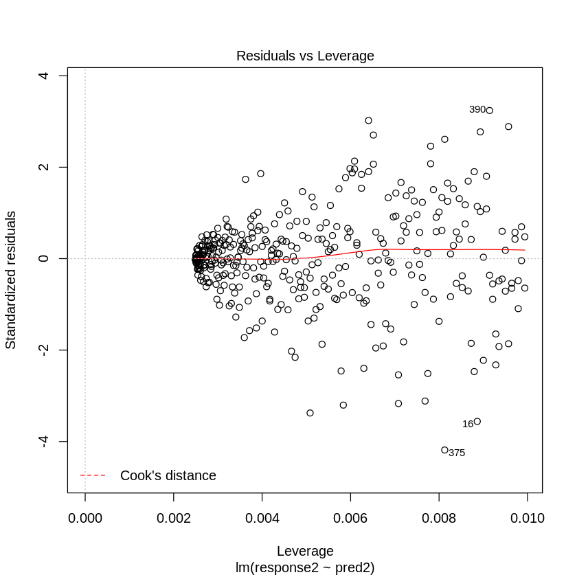

```r
# Your Code Here
pred2 <- seq(-100, 100, 0.5)
response2 <- 2 * pred2 + pred2 * rnorm(n = length(pred2), mean = 0, sd = 0.5)
plot(pred2, response2)

new_df2 <- data.frame(cbind(pred2, response2))
non_var_mod <- lm(response2 ~ pred2, data = new_df2)
fit2 <- fitted(non_var_mod)
res2 <- resid(non_var_mod)

lead2 <- res2[1:200]
trail2 <- res2[2:201]

plot(lead2, trail2)
plot(response2, fit2)
plot(fit2, res2)
plot(non_var_mod)
```

Again, by examining the plot of the fitted values vs the residual values, we can see that the variance of the errors terms is fairly tight in the middle of the plot, but much wider on the tail ends. The points should be spread out similarly throughout if the variance of the error term is actually constant.

#### 1. (c) Independent Errors

Repeat the above process with simulated data that violates the independent errors assumption.

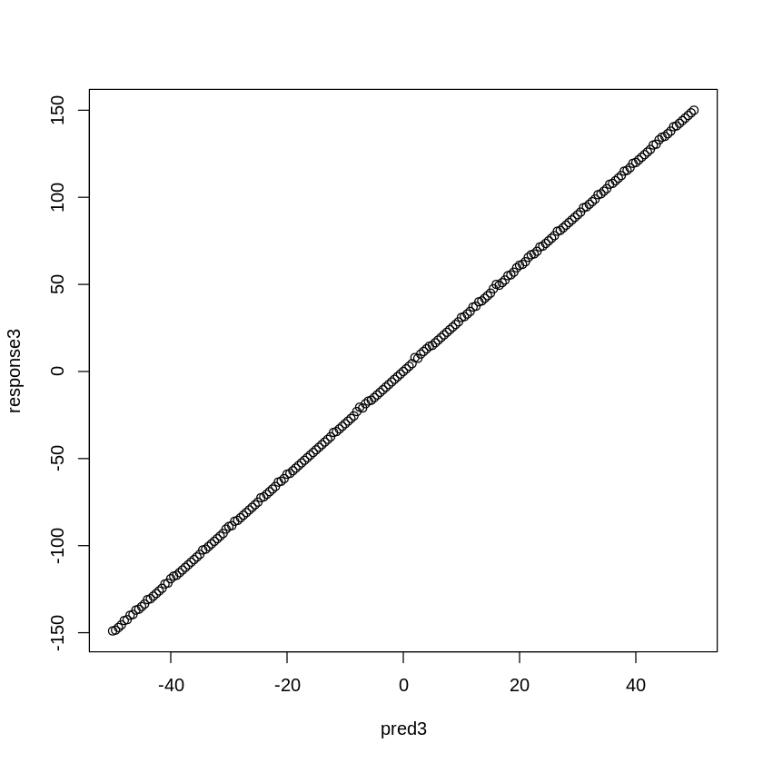

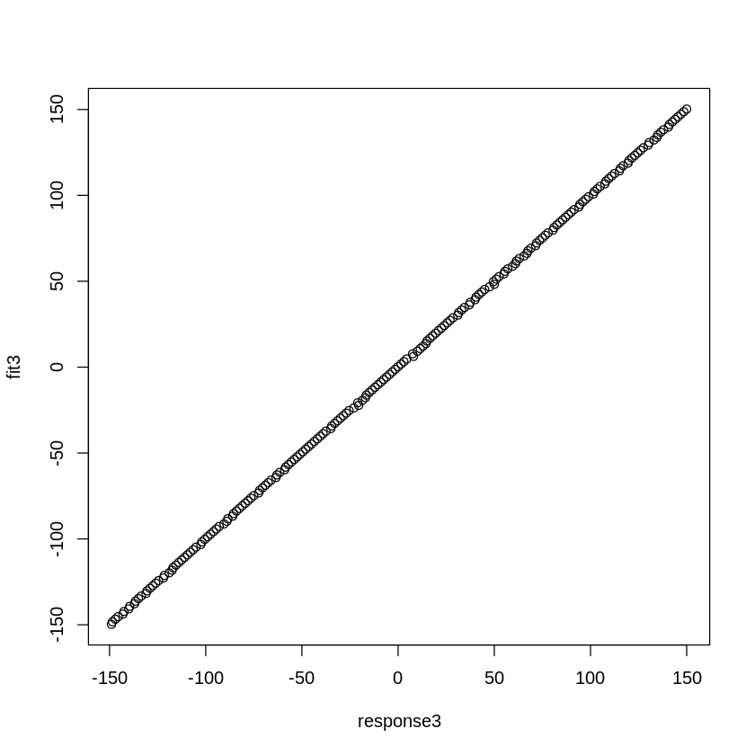

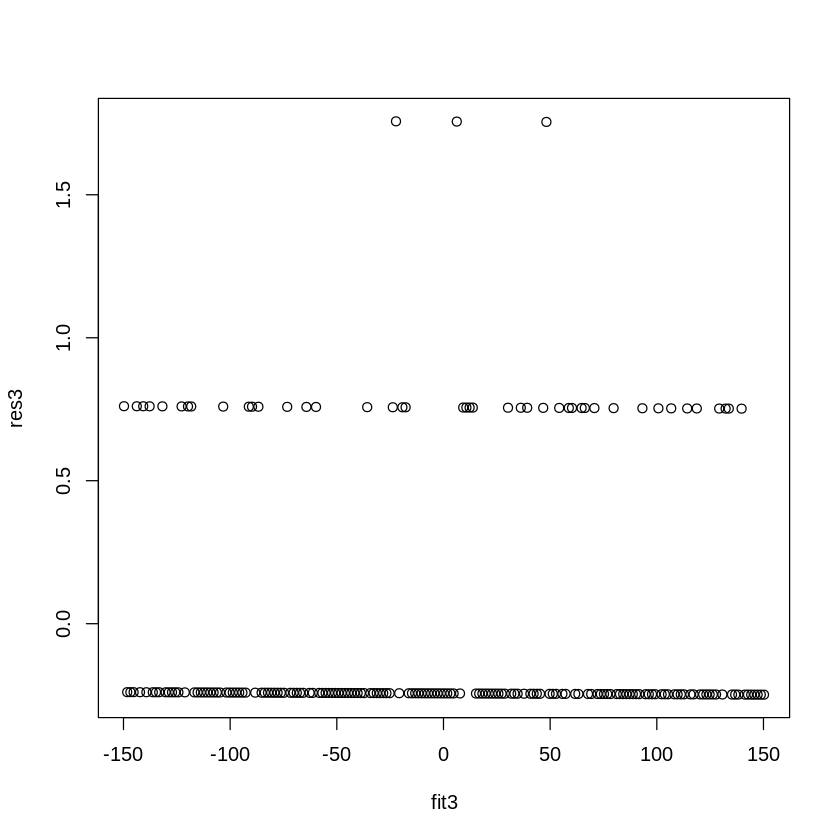

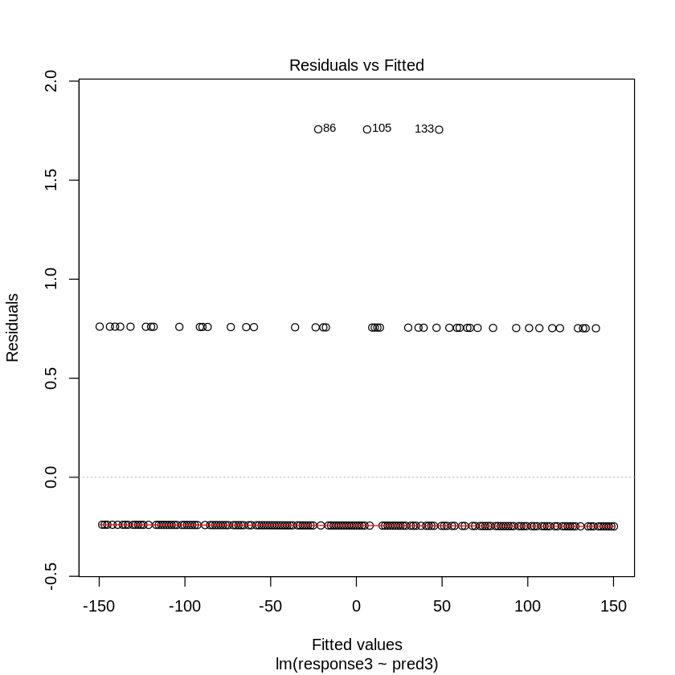

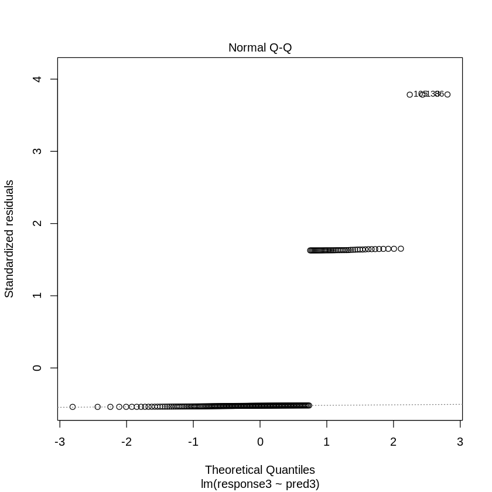

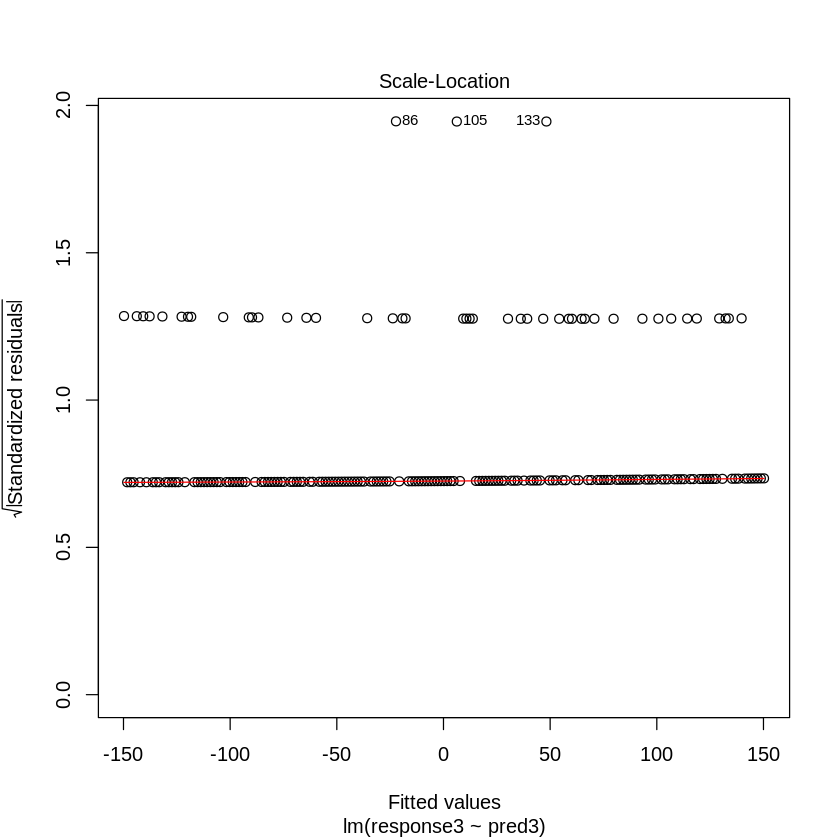

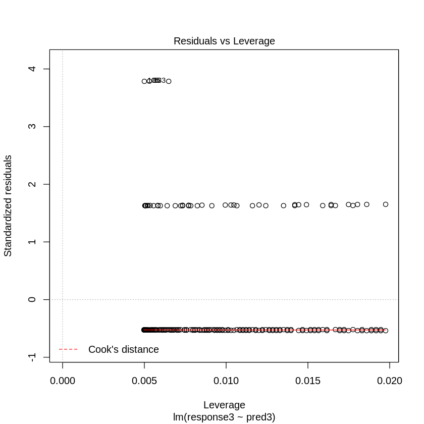

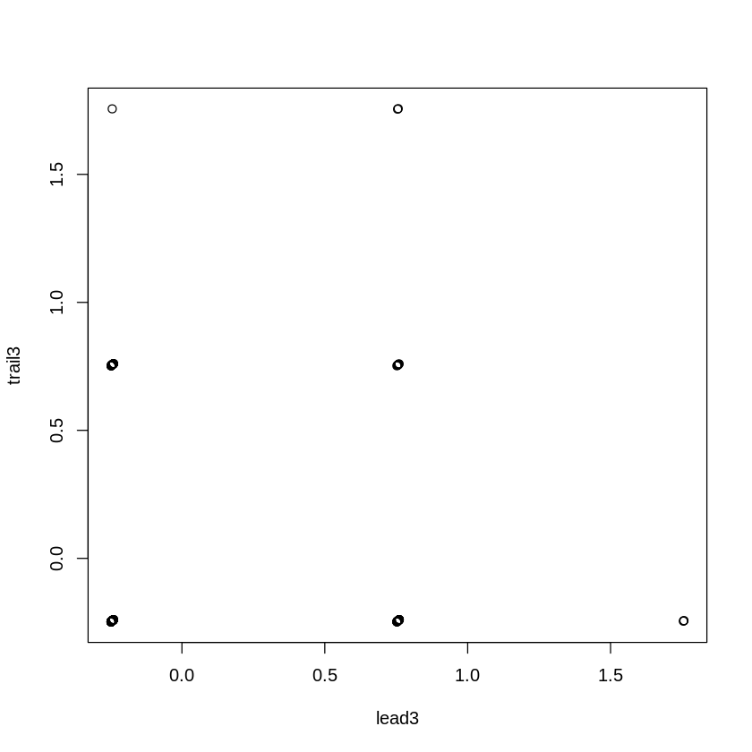

```r
pred3 <- seq(-50, 50, 0.5)
response3 <- 3 * pred3 + rpois(n = length(pred3), lambda = 0.3)
plot(pred3, response3)

new_df3 <- data.frame(cbind(pred3, response3))
non_ind_mod <- lm(response3 ~ pred3, data = new_df3)
fit3 <- fitted(non_ind_mod)
res3 <- resid(non_ind_mod)
#str(res3)
lead3 <- res3[1:200]
trail3 <- res3[2:201]

plot(response3, fit3)
plot(fit3, res3)
plot(non_ind_mod)
plot(lead3, trail3)
```

#### 1. (d) Normally Distributed Errors

Only one more to go! Repeat the process again but simulate the data with non-normal errors.

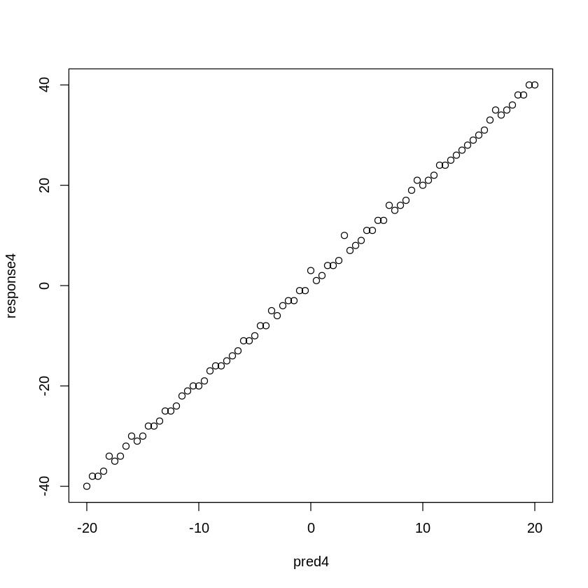

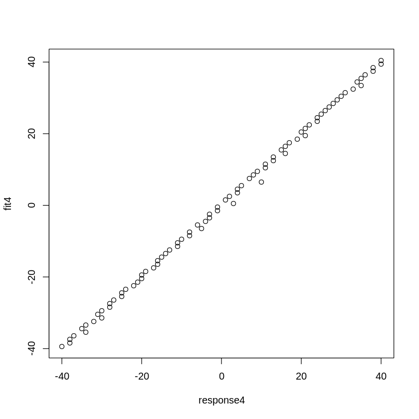

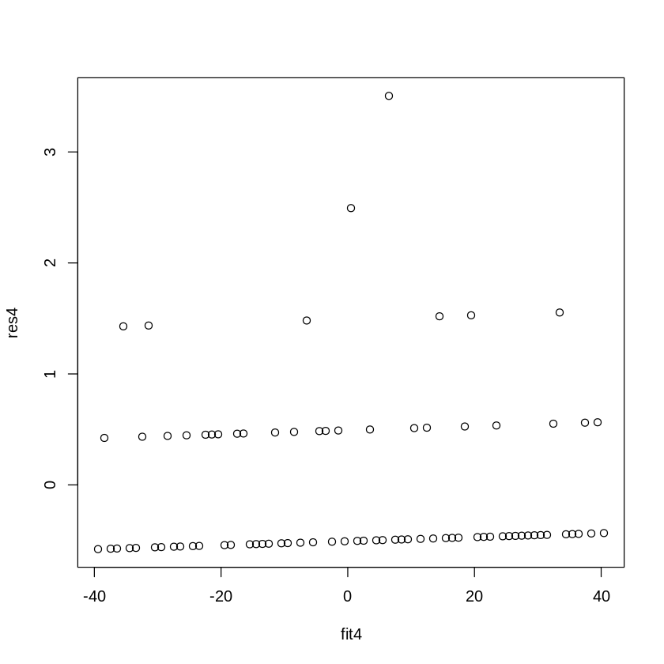

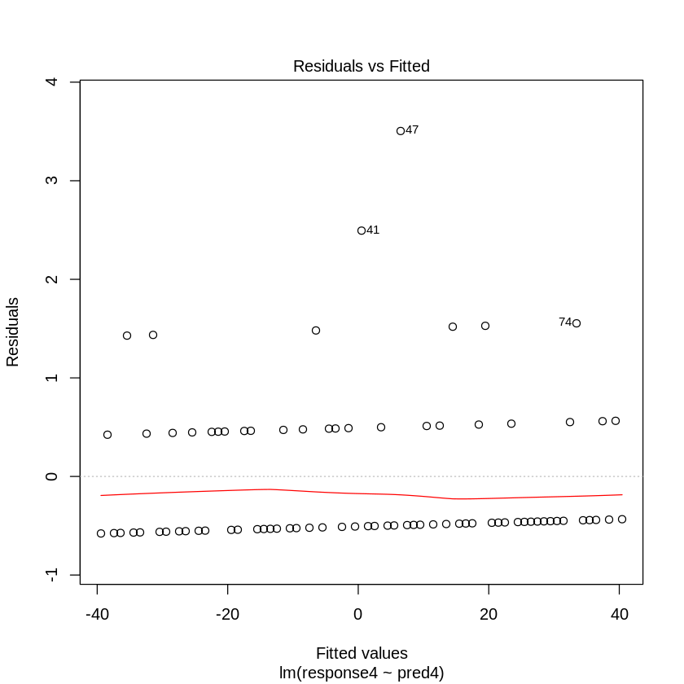

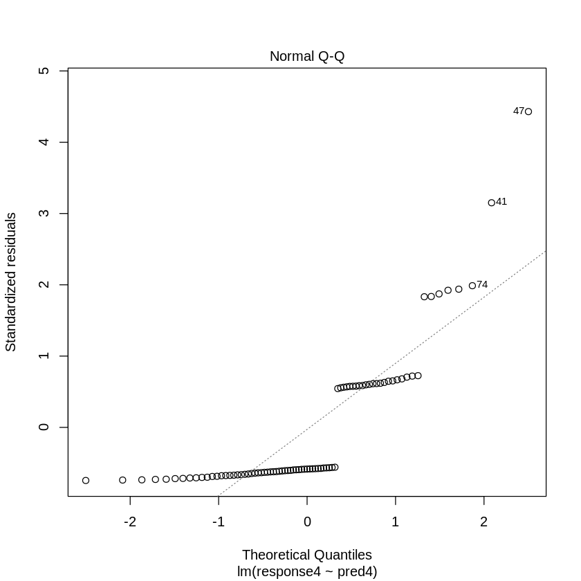

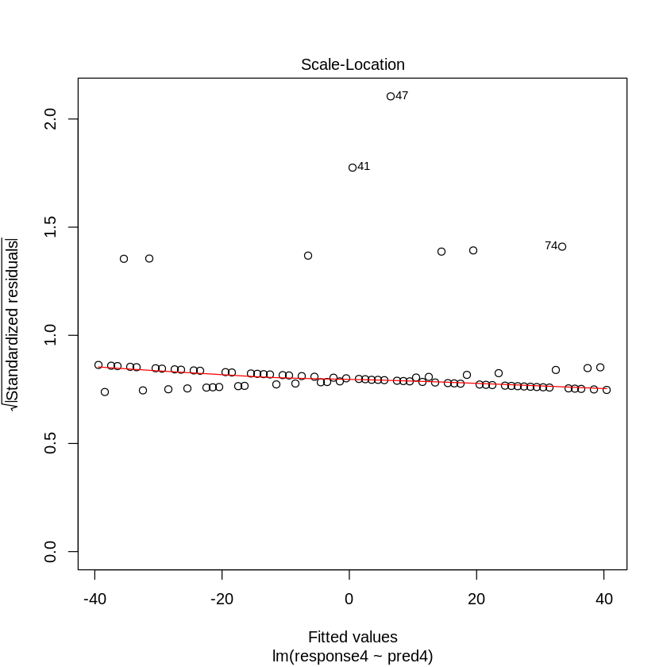

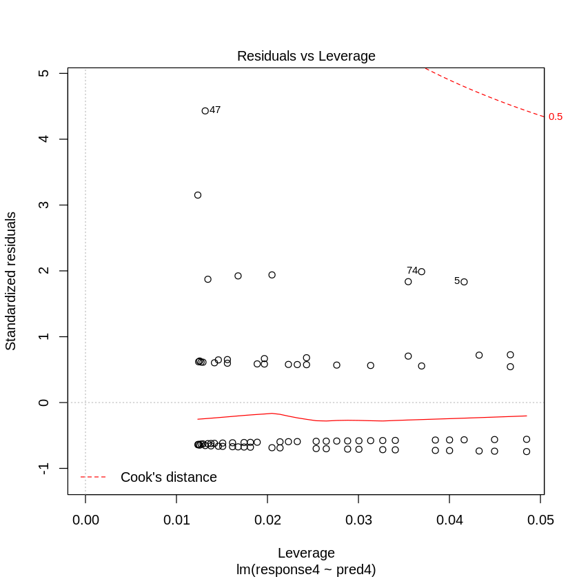

```r
pred4 <- seq(-20, 20, 0.5)
response4 <- 2 * pred4 + rpois(n = length(pred4), lambda = 0.5)
plot(pred4, response4)

new_df4 <- data.frame(cbind(pred4, response4))
non_norm_mod <- lm(response4 ~ pred4, data = new_df4)
fit4 <- fitted(non_norm_mod)
res4 <- resid(non_norm_mod)

plot(response4, fit4)
plot(fit4, res4)
plot(non_norm_mod)
```

By examining the Q-Q plot, we can see that the points are aligned in several different horizontal clusterings instead of following the line y=x. This is indicative of non-normality of the error term.

# Problem 2: Hats for Sale

Recall that the *hat* or *projection* matrix is defined as

$$H = X(X^TX)^{-1}X^T.$$

The goal of this question is to use the hat matrix to prove that the fitted values, $\widehat{\mathbf Y}$, and the residuals, $\widehat{\boldsymbol\varepsilon}$, are uncorrelated. It's a bit of a process, so we will do it in steps.

#### 2. (a) Show that $\widehat{Y} = HY$. That is, $H$ "puts a hat on" $Y$.

$ \hat{Y} = HY $

$ \hat{Y} = X(X^TX)^{-1}X^TY $

$ \hat\beta = (X^TX)^{-1}X^TY $

$ \hat{Y} = X\hat\beta $

$ \hat{Y} = \hat{Y} $

#### 2. (b) Show that $H$ is symmetric: $H = H^T$.

$ H = H^T$

$ H = [X(X^TX)^{-1}X^T]^T $

$ H = X^{T^T} [(X^TX)^{-1}]^T X^T $

$ H = X [(X^TX)^{-1}]^T X^T $

$ H = H $

#### 2. (c) Show that $H(I_n - H) = 0_n$, where $0_n$ is the zero matrix of size $n \times n$.**

$ H(I_n - H) = 0_n $

$ H - H^2 = 0_n $

$ H - [X(X^TX)^{-1}X^T][X(X^TX)^{-1}X^T] = 0 $

$ H - X[(X^TX)^{-1}X^TX](X^TX)^{-1}X^T = 0 $

$ H - X(X^TX)^{-1}X^T = 0 $

$ H - H = 0 $

$ 0 = 0 $

**2. (d) Stating that $\widehat{\mathbf Y}$ is uncorrelated with $\widehat{\boldsymbol\varepsilon}$ is equivalent to showing that these vectors are orthogonal.* That is, we want their dot product to equal zero:**

$$ \widehat{\mathbf Y}^T\widehat{\boldsymbol\varepsilon} = 0.$$

Prove this result. Also explain why being uncorrelated, in this case, is equivalent to the being orthogonal.

$$ \widehat{\mathbf Y}^T\widehat{\boldsymbol\varepsilon} = 0 $$$$ (HY)^T (y - \hat{y}) = 0 $$$$ Y^TH^T (Y - HY) = 0 $$$$ Y^THY - Y^TH^2Y = 0 $$$$ Y^THY - Y^THY = 0 $$$$ 0 = 0 $$

Since the covariance between the fitted and the residuals is zero, they are also considered to be orthogonal to each other.

#### 2.(e) Why is this result important in the practical use of linear regression?

If the residuals were correlated with the response, then the independence of the error terms assumption would be violated.

## Problem 3: Model Diagnosis

We here at the University of Colorado's Department of Applied Math love Bollywood movies. So, let's analyze some data related to them!

We want to determine if there is a linear relation between the amount of money spent on a movie (it's budget) and the amount of money the movie makes. Any venture capitalists among you will certianly hope that there is at least some relation. So let's get to modelling!